# MEDL_PS03_Soln

**Deep Learning for Mechanical Engineering**  
**Homework 03**  
**Due Wednesday, 10/04/2023, 4:00 PM**

Instructor: Prof. Seungchul Lee  
http://iailab.kaist.ac.kr/  
Industrial AI Lab at KAIST

- For your handwritten solution,write it in markdown.
- For your code, only .ipynb file will be graded.
  - Please write your NAME and student ID on your .ipynb files. ex) IljeokKim_20202467_HW02.ipynb
- Please compress all the files to make a single .zip file
  - Please write your NAME and student ID on your .zip files. ex) DogyeomPark_20202467_HW02.zip
  - Submit it to KLMS
- Do not submit a printed version of your code. It will not be graded.

# Problem 1: Gradient Descent

In this problem, we are going to solve the regression problem with batch and stochastic gradient descent methods. The objective of this problem is to compare the loss of each method. Since this problem is simple and convex, the loss would reduce rapidly. So, iterate no more than 100 times. And you do not have to use TensorFlow.

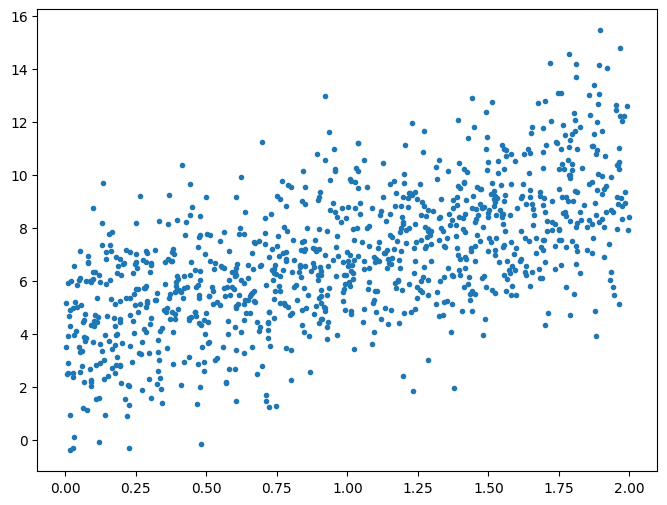

```python
import numpy as np
import tensorflow as tf
import matplotlib.pyplot as plt
import sklearn

m = 1000
x = 2*np.random.rand(m, 1)
y = 4 + 3*x + 2*np.random.randn(m,1)
A = np.hstack((np.ones((m,1)), x))

x = np.asmatrix(x)
y = np.asmatrix(y)
A = np.asmatrix(A)

plt.figure(figsize = (8, 6))
plt.plot(x, y, '.')
plt.show()
```

(1) Find the fitted line with the **batch gradient descent method** and plot the loss.

Note: the loss function for the regression problem is MSE.

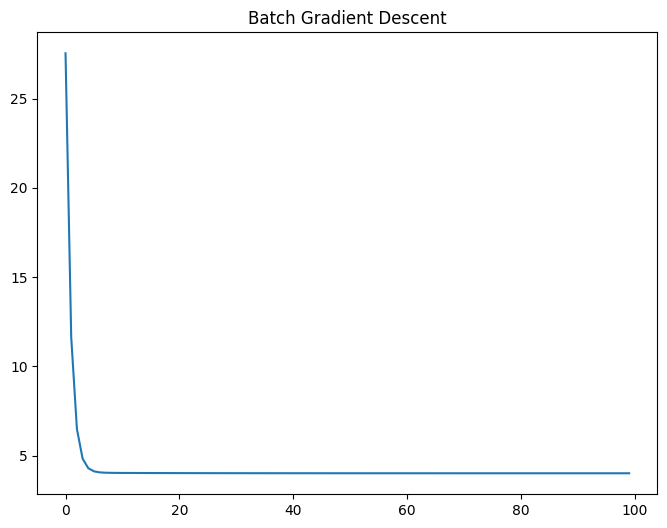

```python
## Solution

LR = 0.1
n_iter = 100

# initialization
theta = np.random.randn(2,1)
Loss = []

# gradient descent
for i in range(n_iter):
    df = 1/m*2*(A.T*A*theta - A.T*y)
    theta = theta - LR*df
    loss = 1/m*np.sum(np.square(A*theta - y))
    Loss.append(loss)

plt.figure(figsize = (8, 6))
plt.plot(Loss)
plt.title('Batch Gradient Descent')
plt.show()
```

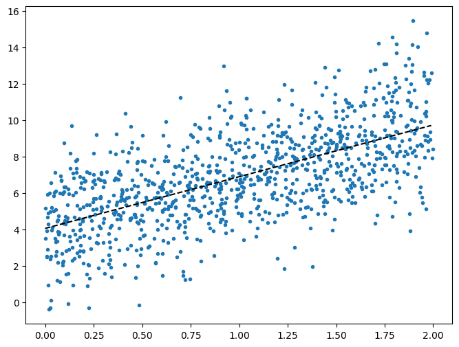

```python
xp = np.arange(0, 2, 0.01).reshape(-1,1)
yp = theta[1,0]*xp + theta[0,0]

plt.figure(figsize = (8, 6))
plt.plot(x, y, '.')
plt.plot(xp, yp, 'k--')

plt.show()
```

(2) Find the fitted line with the **stochastic gradient descent method** and plot the loss.

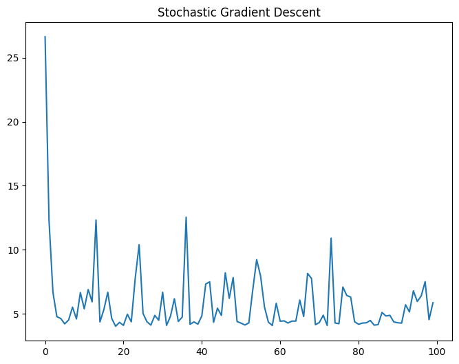

```python
## Solution

LR = 0.1

# initialization
theta = np.random.randn(2,1)
Loss = []

for epoch in range(n_iter):
    idx = np.random.choice(m)
    xi = A[idx]
    yi = y[idx]

    df = 2*(xi.T*xi*theta - xi.T*yi)
    theta = theta - LR*df

    loss = 1/m*np.sum(np.square(A*theta - y))
    Loss.append(loss)

plt.figure(figsize = (8, 6))
plt.plot(Loss)
plt.title('Stochastic Gradient Descent')
plt.show()
```

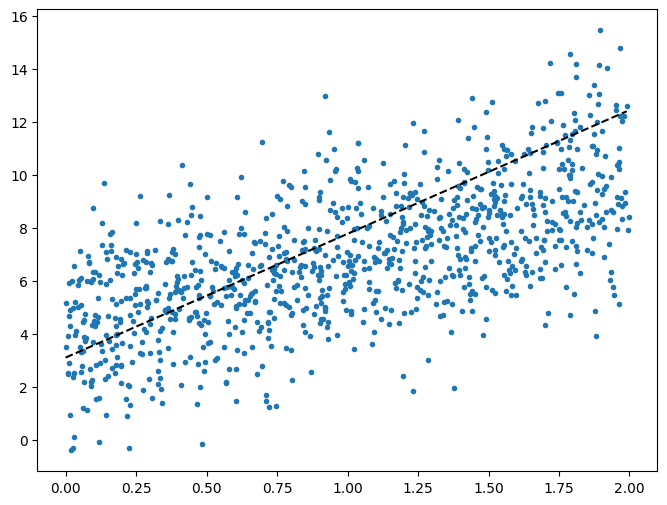

```python
xp = np.arange(0, 2, 0.01).reshape(-1,1)
yp = theta[1,0]*xp + theta[0,0]

plt.figure(figsize = (8, 6))
plt.plot(x, y, '.')
plt.plot(xp, yp, 'k--')

plt.show()
```

(3) In the stochastic gradient descent method, we will add a simple adaptive learning rate. We are going to reduce the learning rate gradually. In other words, use a large learning rate at first and decrease it gradually.

$$\alpha(k) = \frac{1}{k + 10}$$

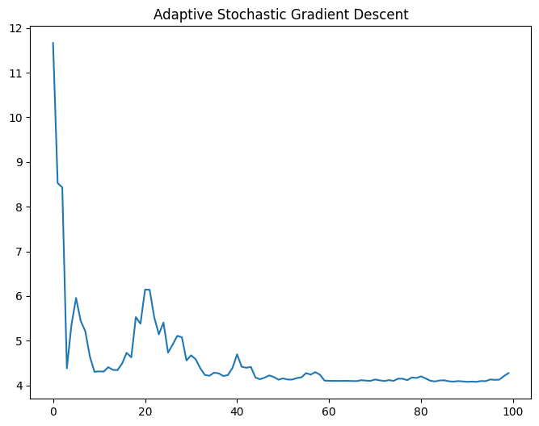

```python
## Solution

def LearningRate(k):
    return 1/(k + 10)

# initialization
theta = np.random.randn(2,1)
Loss = []

for epoch in range(n_iter):
    idx = np.random.choice(m)
    xi = A[idx]
    yi = y[idx]

    df = 2*(xi.T*xi*theta - xi.T*yi)
    theta = theta - LearningRate(epoch)*df

    loss = 1/m*np.sum(np.square(A*theta - y))
    Loss.append(loss)

plt.figure(figsize = (8, 6))
plt.plot(Loss)
plt.title('Adaptive Stochastic Gradient Descent')
# plt.ylim([0, 35])
plt.show()
```

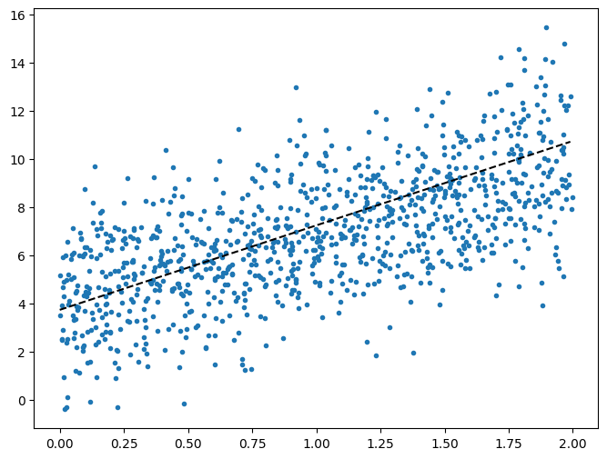

```python
xp = np.arange(0, 2, 0.01).reshape(-1,1)
yp = theta[1,0]*xp + theta[0,0]

plt.figure(figsize = (8, 6))
plt.plot(x, y, '.')
plt.plot(xp, yp, 'k--')

plt.show()
```

# Problem 2: Regularization

The regularized least-squares problem has the form $$ \min_{\theta} \;\lVert A\theta -y\rVert_2^2 + \lambda \lVert \theta \rVert_2^2$$

(a) Show that the solution is given by

$$ \hat{\theta} = \left( A^T A + \lambda I_n \right)^{-1} A^T y $$

- Do not use the method of Lagrangian multipliers

**(sol)** Sum of 2-norms of multiple vectors can be expressed as a 2-norm of a single vector.

$$ \begin{align*} \left\Vert A\theta - y\big\Vert^2_{2} + \big\Vert \sqrt{\lambda}I\theta-0\right\Vert^2_{2} & = \Bigg\Vert \begin{bmatrix} A\\ \sqrt{\lambda}I \end{bmatrix} \theta- \begin{bmatrix} y\\ 0 \end{bmatrix} \Bigg\Vert^2_{2} \end{align*}$$

$$ \hat{\theta} = \left( \begin{bmatrix} A\\ \sqrt{\lambda}I \end{bmatrix}^T \begin{bmatrix} A\\ \sqrt{\lambda}I \end{bmatrix}\right)^{-1}\begin{bmatrix} A\\ \sqrt{\lambda}I \end{bmatrix}^T \begin{bmatrix} y\\ 0 \end{bmatrix} = \left( A^T A + \lambda I_n \right)^{-1} A^T y $$

(b) Write down a gradient descent algorithm for the given optimization problem.

$$ \min_{\theta} \;\lVert A\theta -y\rVert_2^2 + \lambda \lVert \theta \rVert_2^2$$

- Hint: Note that $$ \;\lVert A\theta -y\rVert_2^2 = (A\theta - y)^T(A\theta - y)$$

Then, you can differentiate the above equation to compute the gradient. Likewise, you can compute the gradient of the regularizer.

**(sol)** Let $J(\theta) = \Vert A\theta - y \Vert_2^2 + \lambda \Vert \theta \Vert_2^2$. A gradient descent algorithm is formulated as the following,

$$ \theta \leftarrow \theta - \eta \frac{\partial{J}}{\partial{\theta}}. $$

Need to compute $\frac{\partial{J}}{\partial{\theta}}$.

$$ \begin{align*} g_{\text{projection}} &= \frac{\partial}{\partial{\theta}} \Vert A\theta - y \Vert_2^2 \\ &= \frac{\partial}{\partial{\theta}} (A\theta - y)^T(A\theta - y) \\ &= \frac{\partial}{\partial{\theta}} (\theta^T A^T A \theta - 2\theta^T A^T y - y^Ty) \\ &= 2A^TA \theta - 2A^Ty \\ \\ g_{\text{regularizer}} &= \frac{\partial}{\partial{\theta}} \Vert \theta \Vert_2^2 \\ &= \frac{\partial}{\partial{\theta}} \theta^T \theta \\ &= 2 \theta. \end{align*} $$

Therefore,

$$ \begin{align*} \frac{\partial{J}}{\partial{\theta}} &= g_{\text{projection}} + \lambda g_{\text{regularizer}} \\ &= 2A^TA \theta - 2A^Ty + \lambda 2 \theta. \end{align*} $$

Then, the gradient descent algorithm is formulated as the following

$$ \theta \leftarrow \theta - \eta(2A^TA \theta - 2A^Ty + \lambda 2 \theta). $$

(c) Based on the result of (b), describe the role of regularizer term.

- Hint: Gradient $g$ is computed by $ g = g_{\text{projection}} + g_{\text{regularizer}} $.

**(sol)**

$g_{\text{regularizer}}$ tends to make $\theta$ converge to zero. Since $g = g_{\text{projection}} + \lambda g_{\text{regularizer}}$, we can see that the regularizer $g_{\text{regularizer}}$ tries to keep the value of $\theta$ small.

(d) Describe results of (a) and (b) have the same meaning.

**(sol)**

Likewise, (a) shows that

$$ (A^T A)^{-1} A^Ty \quad \rightarrow \quad (A^T A + \lambda I_n)^{-1} A^Ty. $$

From the solution of (a),

$$ \nabla_\theta^2 f(\theta) = 2\left(A^TA + \lambda I_n \right)^T \geq 0 \quad \left(\because A^TA = \lVert A \rVert^2,\quad \lambda \geq 0 \right)$$

so, this problem is a convex problem

From solution of (b), if the number of iteration become enough, $\theta_{i+1} \approx \theta_i = \hat{\theta} $ in equation $\theta_{i+1} \leftarrow \theta_i - \alpha g\left(\theta_i \right) $, so

$$ \begin{align*} g\left(\hat{\theta} \right) = 2A^TA \theta - 2A^Ty + \lambda 2 \theta = 0\\ \end{align*} $$

$$ \begin{align*} \left( A^T A + \lambda I_n \right)\hat{\theta} = A^T y \end{align*} $$$$ \begin{align*} \therefore \hat{\theta} = \left( A^T A + \lambda I_n \right)^{-1} A^T y \end{align*} $$

Therefore (a) and (b) are the same meaning